# Lab 07 -Data Visualization-Annette Bazan

### Introduction:

**What is data visualization (VIZ)?**

- Graphical presentation of data.

**What are the benefits of data visualization (VIZ)?**

1. Helps with discovering the data patterns
2. Helps with more effective communication
3. Helps non-technical people to understand the data better or easier
4. Helps with understanding the data distribution
5. Helps with discovering the current trends in the dataset

**What are the types of data visualization?** There are 3 types of data visulaization.

1. Univariate Visualization: plotting one variable.
2. Bivariate Visualization: plotting two variables.
3. Multivariate Visualization: plotting more than two variables.

**What are popular types of data visualization plots (Viz) tools/techniques?**

1. Line Plots
2. Bar Plots / Box chart
3. Pie Charts
4. Scatter Plots
5. Histograms
6. Heatmaps

**What are the popular libraries used for data visualization(Viz)?**

1. matplotlib.pyplot
2. seaborn

```python
# Importing libraries

# general libraries
import numpy as np
import pandas as pd
import math

# data visualization libraries
import matplotlib.pyplot as plt
import seaborn as sns

# to suppress warnings library
import warnings
warnings.filterwarnings('ignore')

# 1. These Python libraries for data visualizations are said to be platform independence:
# This means that we can use these libraries on any OS(operating system): Windows, Linux, and IOS
# 2. To enhance the performance of matplotlib, an API has been added to it.
# This API is pyplot.
# * API: Application Programming Interface: Acts as a bridge that connects two or more applications/programs.
```

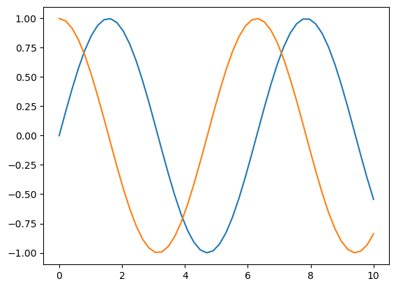

```python
# 1. Line Plots: These are the simplest plots
# They display the progress of an event over time

# Creating the dataset
a = np.linspace(0, 10)

# Plotting the dataset: The sin and cos of the numbers 0-10
plt.plot(a, np.sin(a)) # The sin of 0 is 0
plt.plot(a, np.cos(a)); # The cos of 0 is 1
```

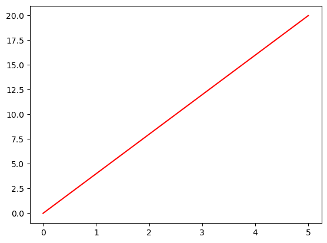

```python
# Creating the dataset
x = np.array([0, 5])
y = np.array([0, 20])

# Plotting the dataset:
plt.plot(x, y, color='red');
```

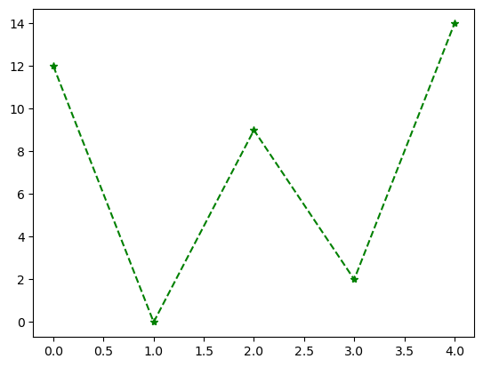

```python
# Creating the dataset
y = np.array([12, 0, 9, 2, 14])

# Plotting the dataset: The sin and cos of the numbers 0-10
plt.plot(y,color ='green', linestyle = 'dashed', marker = '*');
```

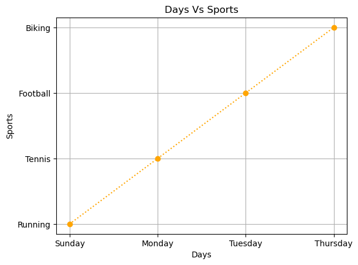

```python
# Creating the dataset
x = pd.Series(['Sunday', 'Monday', 'Tuesday', 'Thursday'])
y = pd.Series(['Running','Tennis', 'Football', 'Biking'])

# Plotting the dataset: The sin and cos of the numbers 0-10
plt.plot(x,y, color = 'orange', marker = 'o', linestyle = ':')
plt.title('Days Vs Sports')
plt.xlabel('Days')
plt.ylabel('Sports')
plt.grid();
```

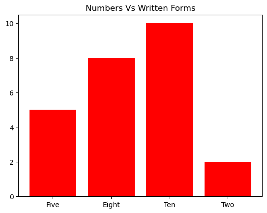

```python
# 2. Bar Plots: These are good to compare various categories.

# Creating the dataset
y = np.array([5, 8, 10, 2])
x = np.array(['Five', 'Eight', 'Ten', 'Two'])

# Plotting the dataset
plt.bar(x,y, color = 'r')
plt.title('Numbers Vs Written Forms');
```

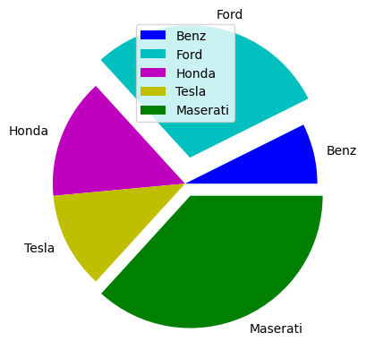

```python
# 3. Pie Charts: These are good to show the proportions over the whole

# Creating the dataset
y = np.array([5, 20, 10, 8, 25])
cars = ['Benz', 'Ford', 'Honda','Tesla', 'Maserati'] # Labels
spaces = [0, 0.2, 0, 0, 0.1] #distances
kolrs = ['b', 'c', 'm','y', 'g']

# Plotting the dataset: The sin and cos of the numbers 0-10
plt.pie(y, labels = cars, explode = spaces, colors = kolrs )
plt.legend();
```

**Color Codes**

1. r for red
2. g for green
3. b for blue
4. c for cyan
5. y for yellow
6. m for magenta
7. k for black
8. w for white

```python
# Let's load the dataset
df = pd.read_csv('titanic.csv')
```

```python
# Creating a copy
titanic = df.copy()
```

```python
# Checking if the dataset loaded
titanic.head()
```

|  | PassengerId | Survived | Pclass | Name | Sex | Age | SibSp | Parch | Ticket | Fare | Cabin | Embarked |
| --- | --- | --- | --- | --- | --- | --- | --- | --- | --- | --- | --- | --- |
| 0 | 1 | 0 | 3 | Braund, Mr. Owen Harris | male | 22.0 | 1 | 0 | A/5 21171 | 7.2500 | NaN | S |
| 1 | 2 | 1 | 1 | Cumings, Mrs. John Bradley (Florence Briggs Th... | female | 38.0 | 1 | 0 | PC 17599 | 71.2833 | C85 | C |
| 2 | 3 | 1 | 3 | Heikkinen, Miss. Laina | female | 26.0 | 0 | 0 | STON/O2. 3101282 | 7.9250 | NaN | S |
| 3 | 4 | 1 | 1 | Futrelle, Mrs. Jacques Heath (Lily May Peel) | female | 35.0 | 1 | 0 | 113803 | 53.1000 | C123 | S |
| 4 | 5 | 0 | 3 | Allen, Mr. William Henry | male | 35.0 | 0 | 0 | 373450 | 8.0500 | NaN | S |

```python
# Theres 891 rows
titanic.tail()
```

|  | PassengerId | Survived | Pclass | Name | Sex | Age | SibSp | Parch | Ticket | Fare | Cabin | Embarked |
| --- | --- | --- | --- | --- | --- | --- | --- | --- | --- | --- | --- | --- |
| 886 | 887 | 0 | 2 | Montvila, Rev. Juozas | male | 27.0 | 0 | 0 | 211536 | 13.00 | NaN | S |
| 887 | 888 | 1 | 1 | Graham, Miss. Margaret Edith | female | 19.0 | 0 | 0 | 112053 | 30.00 | B42 | S |
| 888 | 889 | 0 | 3 | Johnston, Miss. Catherine Helen "Carrie" | female | NaN | 1 | 2 | W./C. 6607 | 23.45 | NaN | S |
| 889 | 890 | 1 | 1 | Behr, Mr. Karl Howell | male | 26.0 | 0 | 0 | 111369 | 30.00 | C148 | C |
| 890 | 891 | 0 | 3 | Dooley, Mr. Patrick | male | 32.0 | 0 | 0 | 370376 | 7.75 | NaN | Q |

### EDA

```python
# 1. Basic data exploration. Let's start with data attributes **can be seperate but also like this
print('Total number of rows and columns are:',titanic.shape)
print('Total number of values are:',titanic.size)
print('The dimensionality of  titanic is:',titanic.ndim)
print('The columns are:', titanic.columns)
print('The data types are:', titanic.dtypes)
```

```
Total number of rows and columns are: (891, 12)
Total number of values are: 10692
The dimensionality of  titanic is: 2
The columns are: Index(['PassengerId', 'Survived', 'Pclass', 'Name', 'Sex', 'Age', 'SibSp',
       'Parch', 'Ticket', 'Fare', 'Cabin', 'Embarked'],
      dtype='object')
The data types are: PassengerId      int64
Survived         int64
Pclass           int64
Name            object
Sex             object
Age            float64
SibSp            int64
Parch            int64
Ticket          object
Fare           float64
Cabin           object
Embarked        object
dtype: object
```

```python
# More information about Titanic
titanic.info()
```

```
<class 'pandas.core.frame.DataFrame'>
RangeIndex: 891 entries, 0 to 890
Data columns (total 12 columns):
 #   Column       Non-Null Count  Dtype
---  ------       --------------  -----
 0   PassengerId  891 non-null    int64
 1   Survived     891 non-null    int64
 2   Pclass       891 non-null    int64
 3   Name         891 non-null    object
 4   Sex          891 non-null    object
 5   Age          714 non-null    float64
 6   SibSp        891 non-null    int64
 7   Parch        891 non-null    int64
 8   Ticket       891 non-null    object
 9   Fare         891 non-null    float64
 10  Cabin        204 non-null    object
 11  Embarked     889 non-null    object
dtypes: float64(2), int64(5), object(5)
memory usage: 83.7+ KB
```

```python
# Let's examine the missing values or NaN(not a number)
titanic.isnull().sum()
```

```
PassengerId      0
Survived         0
Pclass           0
Name             0
Sex              0
Age            177
SibSp            0
Parch            0
Ticket           0
Fare             0
Cabin          687
Embarked         2
dtype: int64
```

```python
# Let's get the statistical summary, These are the only numerical variables thats why there is 7 columns
titanic.describe()
```

|  | PassengerId | Survived | Pclass | Age | SibSp | Parch | Fare |
| --- | --- | --- | --- | --- | --- | --- | --- |
| count | 891.000000 | 891.000000 | 891.000000 | 714.000000 | 891.000000 | 891.000000 | 891.000000 |
| mean | 446.000000 | 0.383838 | 2.308642 | 29.699118 | 0.523008 | 0.381594 | 32.204208 |
| std | 257.353842 | 0.486592 | 0.836071 | 14.526497 | 1.102743 | 0.806057 | 49.693429 |
| min | 1.000000 | 0.000000 | 1.000000 | 0.420000 | 0.000000 | 0.000000 | 0.000000 |
| 25% | 223.500000 | 0.000000 | 2.000000 | 20.125000 | 0.000000 | 0.000000 | 7.910400 |
| 50% | 446.000000 | 0.000000 | 3.000000 | 28.000000 | 0.000000 | 0.000000 | 14.454200 |
| 75% | 668.500000 | 1.000000 | 3.000000 | 38.000000 | 1.000000 | 0.000000 | 31.000000 |
| max | 891.000000 | 1.000000 | 3.000000 | 80.000000 | 8.000000 | 6.000000 | 512.329200 |

```python
# Let's get the summary of the object variables it shows the other 5 columns * there are more males than females in this dataset.(data mining question)
titanic.describe(include = 'object')
```

|  | Name | Sex | Ticket | Cabin | Embarked |
| --- | --- | --- | --- | --- | --- |
| count | 891 | 891 | 891 | 204 | 889 |
| unique | 891 | 2 | 681 | 147 | 3 |
| top | Braund, Mr. Owen Harris | male | 347082 | B96 B98 | S |
| freq | 1 | 577 | 7 | 4 | 644 |

```python
titanic['Survived'].value_counts()
```

```
Survived
0    549
1    342
Name: count, dtype: int64
```

```python
titanic['Age'].value_counts()
```

```
Age
24.00    30
22.00    27
18.00    26
19.00    25
28.00    25
         ..
36.50     1
55.50     1
0.92      1
23.50     1
74.00     1
Name: count, Length: 88, dtype: int64
```

**Observations 1:**

- Using the .value_counts() function with Age in the titanic dataset counts all the ages and gives it a numeric variables.
- There are about 30 people who are 24 years old
- There is one person who is 74 years old

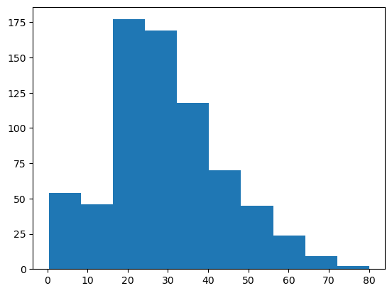

```python
# 4. Histograms: Displays the data distribution
plt.hist(titanic['Age']);
# Right-Skewed or + skewed (the tail goes to the right)
# Numeric variables
```

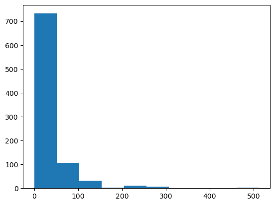

```python
plt.hist(titanic['Fare']);
# Univariate
```

```python
# Value_counts() it gives us the numbers for each category will be on final!
# One of the best functions to be used here is value_counts()
# Let's see the number of male and female in this dataset
titanic['Sex'].value_counts()
```

```
Sex
male      577
female    314
Name: count, dtype: int64
```

**Observations 2:**

- There are 577 males
- There are 314 females
- Age is right skewed due to the tail leaning towards the right, and this is a univariate visualization.

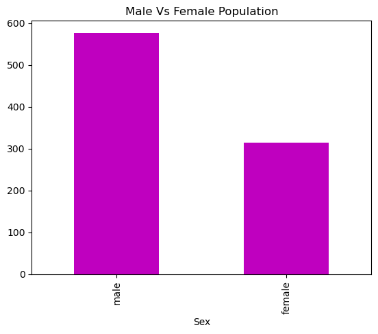

```python
# Plotting the output
titanic['Sex'].value_counts().plot(kind = 'bar', color = 'm')
plt.title('Male Vs Female Population');
```

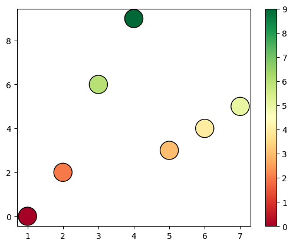

```python
# 5. Scatter plots:These plots show the relationship between variables
# Every dot in the scatter plots represents an observation
# The values from x and y axes should be the same

# Creating the dataset
y = np.array([0, 2, 6, 9, 3, 4, 5])
x = np.array([1, 2, 3, 4, 5, 6, 7])

# Plotting the Scatter Plot:
plt.scatter(x,y, cmap = 'RdYlGn', s = 500, edgecolors = 'black', c=y)
plt.colorbar();
# 9 and 4 is meeting in scatter plot green is the highest number.
```